# SNA_Learn: Networks in Animal Health

Teaching

Hands-on intro to animal movement network analysis in R.

Author

Sara C. Sequeira

Published

September 20, 2025

## 1 Introduction and Example Network

Animal movement connects premises (farms, markets, dealers, raisers, slaughter plants). These connections form **contact networks** that shape **pathogen spread**, **traceability** and **targeting of interventions** (e.g., targeted surveillance, biosecurity implementation and control measures). In this course, we’ll use R to:

- Build and visualize networks of animal movements.
- Visualize networks and annotate nodes by type (state, breed, sex, etc).
- Compute core metrics (in/out-degree, strength, betweenness, components).
- “Slice” networks over time to see how structure changes.

> **Core idea:** Each shipment is typically a **directed edge** from origin → destination, with **weight** = number of animals moved (or shipments). Node attributes capture **premises type** (e.g., Dairy, Dealer, Market) and region (i.e., state, zip code). Edge attributes could be animal details (e.g., breeds, age, sex moved).

### 1.1 Load & Import the dataset

To start, let’s import a typical hypothetical dataset of cattle movements in the US and have a look at the variables.

```r
library(tidyverse)

movements <- readr::read_csv("data/SampleDataset_3m.csv", show_col_types = FALSE)

glimpse(movements)
```

[output not shown]

### 1.2 Identify the nodes - “Nodelist”

Nodes are the entities in our network. In this case, each unique premises (farm, dealer, market, etc.), but it could also be a region. We can list all the unique origins and destinations to define the set of nodes.

```r
# Build node list from both origins and destinations
length(unique(c(movements$origin_name, movements$destination_name))) # how many unique premises?

# if we are interested, we can also add the farm type and state as attributes.
nodes <- movements %>%
  select(origin_name, origin_type, origin_state,
         destination_name, destination_type, destination_state) %>%
  pivot_longer(
    everything(),
    names_to = c("role", ".value"),
    names_pattern = "(origin|destination)_(.*)") %>%
  transmute(prem_id = name, type, state) %>%
  distinct()

# Now quick summaries:
nodes %>% count(type, sort = TRUE)
nodes %>% count(state, sort = TRUE)

nodes %>%
  count(state, type) %>%
  ggplot(aes(x = reorder(state, n), y = n, fill = type)) +
  geom_col() +
  coord_flip() +
  labs(
    title = "Premises by State and Type",
    x = "State",
    y = "Number of Premises",
    fill = "Type") +
  scale_y_continuous(breaks = 0:10) +  # <- only integer ticks
  theme_classic()
```

**Check-in questions:**

- How many different premises could you identify?
- Is there a better represented state?
- What types of premises did you find?

### 1.3 Create an “Edgelist” of movements

In this step, we collapse the raw movement records into what we call an edgelist.

> Each row represents a directed connection from an origin premises to a destination premises. Along with the connection itself, we summarize two key attributes: **shipments** = the total number of movements between that pair of premises; **animals** = the total number of head(s) moved across all those shipments

This edgelist is the backbone of the network: it defines the edges (links) between premises and stores attributes that can later be used to **weight** connections later on (e.g., thicker arrows for more shipments moved, larger nodes for more animals moved).

```r
edges <- movements %>%
  group_by(origin_name, destination_name) %>%
  summarise(
    shipments = n(),
    animals   = sum(head),
    .groups   = "drop"
  )

head(edges)
```

### 1.4 Visualize the network - *Igraph* Package

Seems like we have all set. What now? The *igraph* R package makes our life simple.

> **Igraph** is a library and R package for network analysis, providing a pain-free implementation of graph algorithms and fast handling of large graphs that have millions of nodes and edges. By using this package, we create a special object of class **“IGRAPH”**.

For example:

```r
library(igraph)
g <- graph_from_edgelist(
  matrix(c("A","B","B","C","C","A"), ncol=2, byrow=TRUE),
  directed = TRUE)
g
```

```
IGRAPH 5430ac2 DN-- 3 3 --
+ attr: name (v/c)
+ edges from 5430ac2 (vertex names):
[1] A->B B->C C->A
```

```r
class(g)
```

```
[1] "igraph"
```

```r
is.simple(g)
```

```
[1] TRUE
```

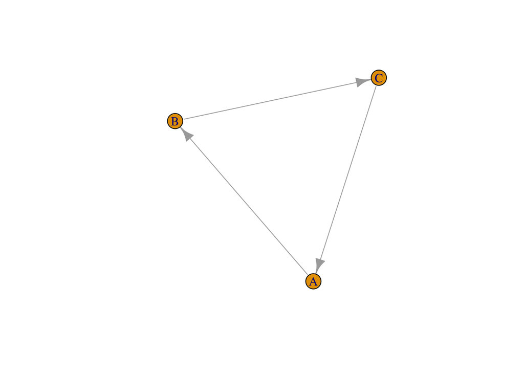

```r
# Let's visualize the network!
plot(g)
```

```r
# How many nodes/vertices does it have?
V(g)
```

```
+ 3/3 vertices, named, from 5430ac2:
[1] A B C
```

```r
# How many edges?
E(g)
```

```
+ 3/3 edges from 5430ac2 (vertex names):
[1] A->B B->C C->A
```

*Igraph* assumes, by default, that our network is directed. If we want to explicitly set it as undirected:

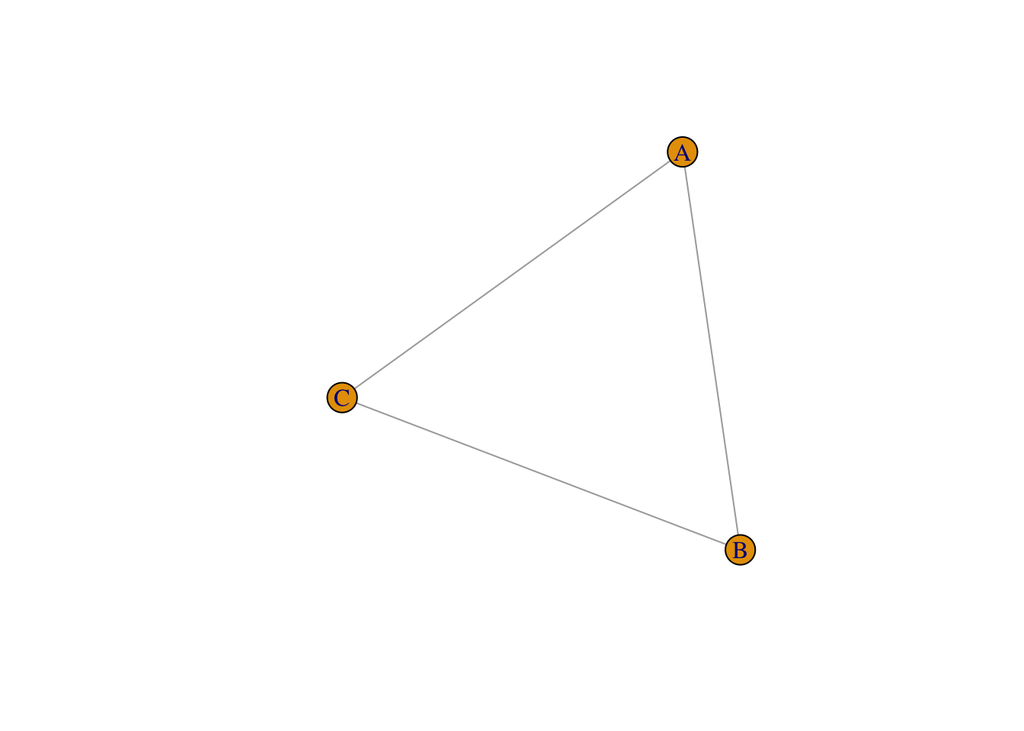

```r
g_undirected <- graph_from_edgelist(
  matrix(c("A","B","B","C","C","A"), ncol=2, byrow=TRUE),
  directed = FALSE)
plot(g_undirected)
```

#### Let’s now visualize our animal movement network!

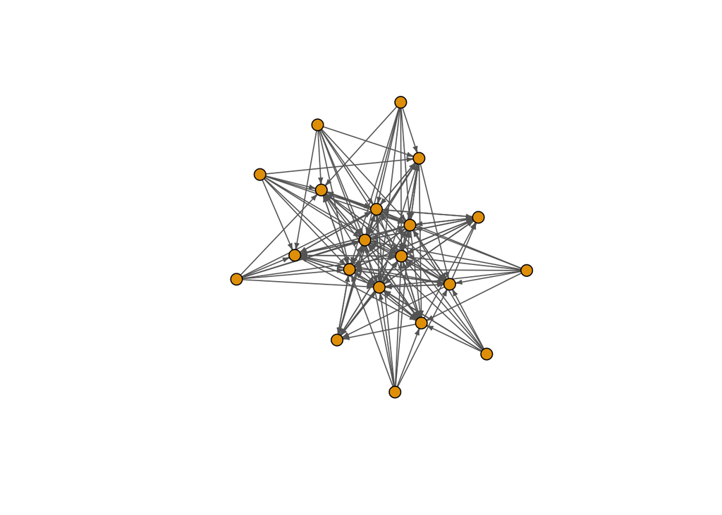

```r
library(igraph)
g <- graph_from_data_frame(
  d = edges,
  vertices = nodes,   # your node list with attributes
  directed = TRUE)

plot(g,
  layout = layout_with_fr(g),
  vertex.size = 8,
  vertex.label = NA,
  edge.arrow.size = 0.3,
  edge.color = "grey40")
```

### 1.5 The 5-Number Summary Stats

Now that we’ve visualized our animal movement network, the next step is to quantify its structure with a five simple statistics:

#### **1. Size**

Total number of nodes (premises) and edges (movements) in the network.

- How many premises and movements do we observe?

```r
# How many nodes/vertices does it have?
V(g)
vcount(g)

# How many edges?
E(g)
ecount(g)
```

#### **2. Density**

Proportion of actual edges to the maximum possible edges.

- How “connected” is our system compared to a fully connected network?

```r
edge_density(g, loops = FALSE)
```

#### **3. Number of components**

The number of subgroups of nodes where everyone is connected directly or indirectly.

- Are there isolated clusters of premises not linked to the rest?

```r
components(g, mode = "weak")$no  # number of weakly connected components
components(g, mode = "strong")$no  # number of strongly connected components
```

**Check-in question:**

- Why is the number of weakly connected components different than the strongly connected components?

```r
plot(g,
  layout = layout_with_fr(g),
  vertex.size = 8,
  vertex.label = NA,
  vertex.color = components(g, mode = "strong")$membership,  # each component gets its own color
  edge.arrow.size = 0.3,
  edge.color = "grey40"
)
```

#### **4. Average Path Length and/or Diameter**

**Diameter** is the single longest shortest path between any two nodes (i.e., informs about the extent of a possible disease outbreak), while the **Average Path Length** is the mean of all shortest paths (i.e., informs the mean distance an outbreak would reach).

- On average, how many steps separate one premises from another? What about the maximum distance?

```r
mean_distance(g, directed = FALSE)
diameter(g, directed = FALSE)
```

#### **5. Clustering Coefficient (or Transitivity)**

Probability that two connected nodes’ neighbors are also connected. I will be zero if there are no triangles, or 1 if all neighbors of nodes connect to each other.

- Do we see “triangles” (tight local clusters) in our network?

```r
transitivity(g, type = "global")
```

### 1.6 Node Centrality

We can also calculate measures that capture some more general notion of ‘importance’ of a node - typically referred to as **node/vertex centrality measures**. Some of them include degree (in-degree, out-degree or total degree), weighted degree or strength (in-strength, out-strength or total strength), closeness and betweenness centrality.

#### **1) Degree**

What is the degree in this network, as represented in the graph?

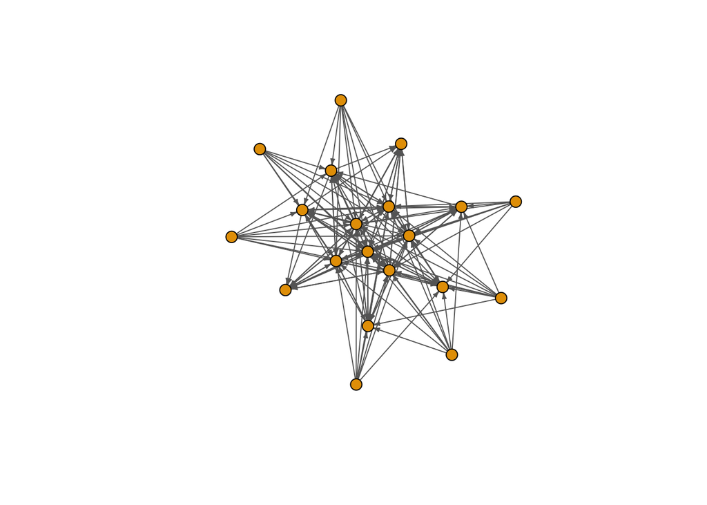

[output not shown]

#### **1.1. What if we want to add weights to our degree explicitly?**

Instead of simply counting the number of edges (degree), we can account for the **magnitude of movements** by summing up the edge weights:

```r
# Total animals moved (in + out)
V(g)$strength_animals_total <- strength(g, mode = "all", weights = E(g)$animals)

# Total shipments moved (in + out)
E(g)$weight <- E(g)$shipments
```

Once we defined our weights, we can visualize it!

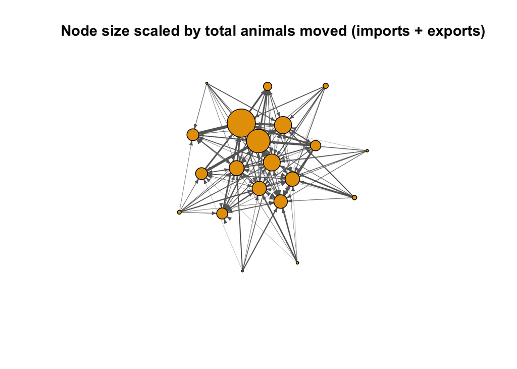

```r
# Plot scaled by total animals moved
plot(g,
  layout = layout_with_fr(g),
  vertex.size = scales::rescale(V(g)$strength_animals_total, to = c(2,30)),
  vertex.label = NA,
  edge.width  = scales::rescale(E(g)$weight, to = c(0.01, 4)),
  edge.arrow.size = 0.3,
  edge.color = "grey40",
  main = "Node size scaled by total animals moved (imports + exports)")
```

It already tells us way more information about the role of premises in the network, right? It might be helpful to **distinguish different node types** by color (what type of premises have more connections?):

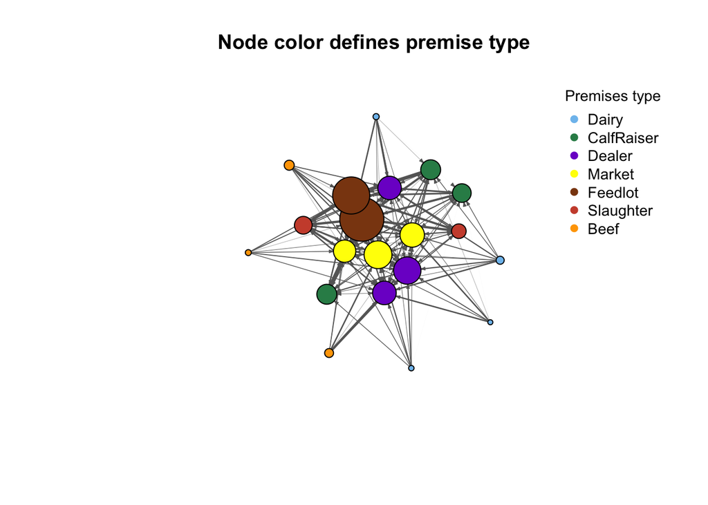

```r
# Define your palette
pal <- c(Dairy = "skyblue2",
    CalfRaiser = "seagreen",
    Dealer     = "purple3",
    Market     = "yellow",
    Feedlot    = "saddlebrown",
    Slaughter  = "tomato3",
    Beef       = "orange")

# Assign colors
types <- as.character(V(g)$type)
cols  <- pal[types]
V(g)$color <- cols

set.seed(42)
{
  plot(g,
    layout = layout_with_fr(g),
    vertex.size  = scales::rescale(V(g)$strength_animals_total, to = c(4,35)),
    vertex.color = V(g)$color,
    vertex.label = NA,
    edge.width   = scales::rescale(E(g)$weight, to = c(0.01, 4)),
    edge.arrow.size = 0.2,
    edge.color  = "grey40",
    main = "Node color defines premise type"
  )
  legend("topright",
         legend = intersect(names(pal), unique(as.character(V(g)$type))),
         col    = pal[intersect(names(pal), unique(as.character(V(g)$type)))],
         pch = 19, bty = "n", cex = 0.9, title = "Premises type")
}
```

#### **1.2. We can also explore** In-Degree** and **Out-Degree** seperately!**

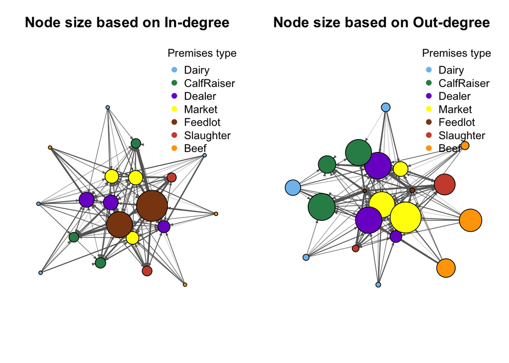

```r
# Total animals moved (in + out)
V(g)$strength_animals_in <- strength(g, mode = "in", weights = E(g)$animals)
V(g)$strength_animals_out <- strength(g, mode = "out", weights = E(g)$animals)


in_out_plot <- par(mfrow = c(1,2), mar = c(1,1,3,1))

{
  plot(g,
    layout = layout_with_fr(g),
    vertex.size  = scales::rescale(V(g)$strength_animals_in, to = c(4,35)),
    vertex.color = V(g)$color,
    vertex.label = NA,
    edge.width   = scales::rescale(E(g)$weight, to = c(0.01, 4)),
    edge.arrow.size = 0.2,
    edge.color  = "grey40",
    main = "Node size based on In-degree")
  legend("topright",
         legend = intersect(names(pal), unique(as.character(V(g)$type))),
         col    = pal[intersect(names(pal), unique(as.character(V(g)$type)))],
         pch = 19, bty = "n", cex = 0.9, title = "Premises type")

  plot(g,
    layout = layout_with_fr(g),
    vertex.size  = scales::rescale(V(g)$strength_animals_out, to = c(4,35)),
    vertex.color = V(g)$color,
    vertex.label = NA,
    edge.width   = scales::rescale(E(g)$weight, to = c(0.01, 4)),
    edge.arrow.size = 0.2,
    edge.color  = "grey40",
    main = "Node size based on Out-degree")
  legend("topright",
         legend = intersect(names(pal), unique(as.character(V(g)$type))),
         col    = pal[intersect(names(pal), unique(as.character(V(g)$type)))],
         pch = 19, bty = "n", cex = 0.9, title = "Premises type")
}
```

Back to top